# SVD Draft

# Overview

### Understanding Rank

A matrix has rank k if its columns (or its rows) span a subspace of dimension k (i.e. there are k pivots in the RREF). However we have some equivalent definitions.

- Rank-0: Zero matrix
- Rank-1: All rows are multiples of each other, $A=uv^T$.

Example of Rank-1: $u=\pmatrix{x\\y\\z}$ and $v^T=(a,b,c)$ so $uv^T=\pmatrix{ax&bx&cx\\ay&by&cy\\az&bz&cz}$ $\leftarrow$ every column is a multiple of $u$ and every row is a multiple of $v$

- Rank-$k$: $A=\sum\limits_{i=1}^{k}u_iv_i^T$, $A=YZ^T$ where $Y$ is $m\times k$, $Z^T$ is $k\times n$

### Low-Rank Approximation

A given matrix $A$ has a large dimension $m\times n$ ($mn$ elements) but using $A=YZ^T$ we get two matrices with $mk+nk$ elements. If $k$ is small then we have much fewer elements.

### Singular Value Decomposition

Singular Value Decomposition works for general matrices. Basically, any $m\times n$ matrix $A$ can be written as $A=USV^T$ where:

- $U$: $m\times m$ orthogonal matrix (left singular vectors)
- $V$: $n\times n$ orthogonal matrix (right singular vectors)
- $S$: $m\times n$ diagonal matrix with non-negative entries (called singular values)

We can calculate SVD for a given matrix in Matlab using the command `[U,S,V] = svd(A)`

Singular Values($\sigma$) are the square root of a $A^TA$’s positive nonzero eigenvalues. The values of the main diagonal of matrix $S$ are the singular values.

SVD expresses $A$ as a weighted sum of rank-1 components ordered by importance ($s_1\geq s_2\geq \cdots \geq s_r$).

### Computing Low-Rank Approximations

Rank-$k$ approximation: - Keep only the top $k$ singular values and vectors:
$$A_k=\sum\limits_{i=1}^ks_iu_iv_i=U_kS_kV_k^T$$
Where:

$U_k$ is first $k$ columns of $U$,

$S_k$ is $k\times k$ diagonal matrix of top singular values,

$V_k$ is first $k$ columns of $V$

### Choosing $k$

Choose $k$ such that:
$$\frac{\sum\limits_{i=1}^ks_i^2}{\sum\limits_{j=1}^{\text{min}(m,n)}s_j^2}\geq 0.9$$
so that 90% of the total variance is retained.

# Practice

Take a sample graph of six people:

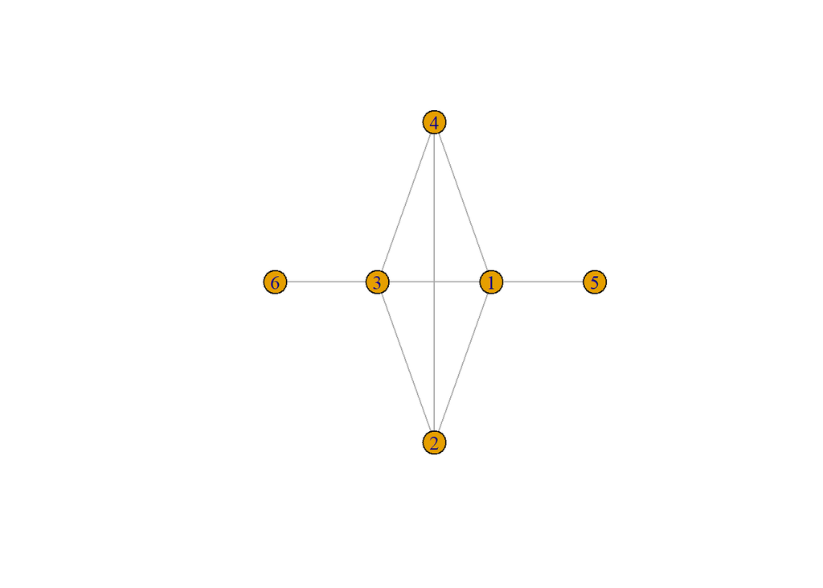

where 1, 2, 3, and 4 are all close friends in a friend group, but 1 is also friends with 5, and 3 is friends with 6. Through low-rank approximation we want to find a prediction that 5 and 6 should be friends.

The summary matrices are:

```r
degree_matrix <-
  matrix(c(4,0,0,0,0,0,0,3,0,0,0,0,0,0,4,0,0,0,0,0,0,3,0,0,0,0,0,0,1,0,0,0,0,0,0,1),
                    nrow = 6, ncol = 6)
```

$$D=\pmatrix{
4 & 0 & 0 & 0 & 0 & 0 \\
0 & 3 & 0 & 0 & 0 & 0 \\
0 & 0 & 4 & 0 & 0 & 0 \\
0 & 0 & 0 & 3 & 0 & 0 \\
0 & 0 & 0 & 0 & 1 & 0 \\
0 & 0 & 0 & 0 & 0 & 1}$$

```r
adjacency <- matrix(
  c(0,1,1,1,1,0,1,0,1,1,0,0,1,1,0,1,0,1,1,1,1,0,0,0,1,0,0,0,0,0,0,0,1,0,0,0),
  nrow = 6, ncol = 6
)
```

$$A=\pmatrix{
0 & 1 & 1 & 1 & 1 & 0 \\
1 & 0 & 1 & 1 & 0 & 0 \\
1 & 1 & 0 & 1 & 0 & 1 \\
1 & 1 & 1 & 0 & 0 & 0 \\
1 & 0 & 0 & 0 & 0 & 0 \\
0 & 0 & 1 & 0 & 0 & 0
}$$

```r
laplacian <- degree_matrix - adjacency
```

$$L=\pmatrix{
4 & -1 & -1 & -1 & -1 & 0 \\
-1 & 3 & -1 & -1 & 0 & 0 \\
-1 & -1 & 4 & -1 & 0 & -1 \\
-1 & -1 & -1 & 3 & 0 & 0 \\
-1 & 0 & 0 & 0 & 1 & 0 \\
0 & 0 & -1 & 0 & 0 & 1
}$$

```r
prob <- adjacency %*% solve(degree_matrix)
```

### Find low-rank approximation of $M$

1. **Calculate SVD of $M$:**

Use the R code: `svd(M)` to get:

```r
list2env(svd(prob), envir = .GlobalEnv)
```

```
<environment: R_GlobalEnv>
```

$$U=\pmatrix{
-0.6789 & 0.7057 & -0.1946 & 0 & 0.0439 & -0.0356 \\
-0.1931 & 0 & 0.6241 & 0.7071 & 0 & 0.2706 \\
-0.6789 & -0.7057 & -0.1946 & 0 & -0.0439 & -0.0356 \\
-0.1931 & 0 & 0.6241 & -0.7071 & 0 & 0.2706 \\
-0.0430 & -0.0439 & 0.2695 & 0 & 0.7057 & -0.6523 \\
-0.0430 & 0.0439 & 0.2695 & 0 & -0.7057 & -0.6523
}$$

$$S=\pmatrix{
1.2687 & 0 & 0 & 0 & 0 & 0 \\
0 & 1.0327 & 0 & 0 & 0 & 0 \\
0 & 0 & 0.5539 & 0 & 0 & 0 \\
0 & 0 & 0 & 0.3333 & 0 & 0 \\
0 & 0 & 0 & 0 & 0.2421 & 0 \\
0 & 0 & 0 & 0 & 0 & 0.1186
}$$

$$V=\pmatrix{
-0.2183 & -0.1815 & 0.5972 & 0 & 0.6834 & -0.3094 \\
-0.4075 & 0 & 0.1414 & -0.7071 & 0 & 0.5604 \\
-0.2183 & 0.1815 & 0.5972 & 0 & -0.6834 & -0.3094 \\
-0.4075 & 0 & 0.1414 & 0.7071 & 0 & 0.5604 \\
-0.5351 & 0.6834 & -0.3513 & 0 & 0.1815 & -0.3004 \\
-0.5351 & -0.6834 & -0.3513 & 0 & -0.1815 & -0.3004
}$$

2. **Choose $k$**

We need a $k$ that retains the sum of squares of singular values. We can get our singular values from the diagonal values of our $S$ matrix.

Our singular values are $\sigma_1=1.2687$, $\sigma_2=1.0327$,$\sigma_3=0.5539$, $\sigma_4=\frac{1}{3}$, $\sigma_5=0.2421$, and $\sigma_6=0.1186$

The sum of the squares of these values is $\sum\limits_{i=1}^6\sigma_i^2=3.167$

$$\frac{2.983}{3.167}=.942$$
So, $k=3$ works!

```r
k <- 3
```

### Computing the low-rank approximation

Using $k=3$:

```r
u_k <- u[,-c(k+1:6)]
```

$$U_3=\pmatrix{
-0.6789 & 0.7057 & -0.1946 \\
-0.1931 & 0 & 0.6241 \\
-0.6789 & -0.7057 & -0.1946 \\
-0.1931 & 0 & 0.6241 \\
-0.0430 & -0.0439 & 0.2695 \\
-0.0430 & 0.0439 & 0.2695
}$$

```r
d_k <- d[0:k]
s_k <- matrix(c(d_k[1],0,0,0,d_k[2],0,0,0,d_k[3]),nrow = 3, ncol = 3)
```

$$S_3=\pmatrix{
1.2687 & 0 & 0 \\
0 & 1.0327 & 0 \\
0 & 0 & 0.5539
}$$

```r
v_k <- v[,-c(k+1:6)]
v_kT <- t(v_k)
```

$$V_3=\pmatrix{
-0.2183 & -0.1815 & 0.5972 \\
-0.4075 & 0 & 0.1414 \\
-0.2183 & 0.1815 & 0.5972 \\
-0.4075 & 0 & 0.1414 \\
-0.5351 & 0.6834 & -0.3513 \\
-0.5351 & -0.6834 & -0.3513
}
\rightarrow
V_3^T=\pmatrix{
-0.2183 & -0.4075 & -0.2183 & -0.4075 & -0.5351 & -0.5351 \\
-0.1815 & 0 & 0.1815 & 0 & 0.6834 & -0.6834 \\
0.5972 & 0.1414 & 0.5972 & 0.1414 & -0.3513 & -0.3513
}$$

```r
prob_k <- u_k %*% s_k %*% v_kT
```

$$M_3=U_3S_3V_3^T$$

$$M_3=
\pmatrix{
-0.6789 & 0.7057 & -0.1946 \\
-0.1931 & 0 & 0.6241 \\
-0.6789 & -0.7057 & -0.1946 \\
-0.1931 & 0 & 0.6241 \\
-0.0430 & -0.0439 & 0.2695 \\
-0.0430 & 0.0439 & 0.2695}
\pmatrix{
1.2687 & 0 & 0 \\
0 & 1.0327 & 0 \\
0 & 0 & 0.5539}
\pmatrix{
-0.2183 & -0.4075 & -0.2183 & -0.4075 & -0.5351 & -0.5351 \\
-0.1815 & 0 & 0.1815 & 0 & 0.6834 & -0.6834 \\
0.5972 & 0.1414 & 0.5972 & 0.1414 & -0.3513 & -0.3513}$$

$$M_3=\pmatrix{
-0.0086 & 0.3357 & 0.2559 & 0.3357 & 0.9968 & 0.0007 \\
0.2599 & 0.1487 & 0.2599 & 0.1487 & 0.0097 & 0.0097 \\
0.2559 & 0.3357 & -0.0086 & 0.3357 & 0.0007 & 0.9968 \\
0.2599 & 0.1487 & 0.2599 & 0.1487 & 0.0097 & 0.0097 \\
0.1093 & 0.0433 & 0.0928 & 0.0433 & -0.0542 & 0.0077 \\
0.0928 & 0.0433 & 0.1093 & 0.0433 & 0.0077 & -0.0542
}$$

# Condensed code:

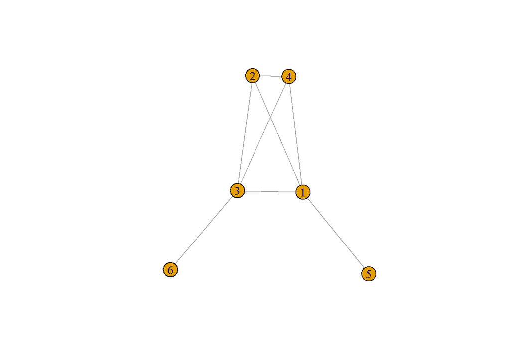

```r
# First make the graph:

a = make_graph(edges = c(1,2,1,3,1,4,2,3,2,4,3,4,1,5,3,6), n = 6, directed = FALSE)
plot(a)
```

```r
# Now we can make the degree matrix and the adjacency matrix
## I'm sure there's a way to have r do this from the graph I just didn't feel like figuring it out
# Put them in by hand :(

degree_matrix <-
  matrix(c(4,0,0,0,0,0,0,3,0,0,0,0,0,0,4,0,0,0,0,0,0,3,0,0,0,0,0,0,1,0,0,0,0,0,0,1),
                    nrow = 6, ncol = 6)

adjacency <- matrix(
  c(0,1,1,1,1,0,1,0,1,1,0,0,1,1,0,1,0,1,1,1,1,0,0,0,1,0,0,0,0,0,0,0,1,0,0,0),
  nrow = 6, ncol = 6
)
```

```r
# Find laplacian and probability matrix

laplacian <- degree_matrix - adjacency

prob <- adjacency %*% solve(degree_matrix)
```

```r
# Do SVD

list2env(svd(prob), envir = .GlobalEnv) #list2env just separates the list
```

```
<environment: R_GlobalEnv>
```

```r
# Decide on a k
k <- 3 #fill in with your own number
```

```r
# Find low rank approximation :)

u_k <- u[,-c(k+1:6)]

d_k <- d[0:k]

s_k <- matrix(c(d_k[1],0,0,0,d_k[2],0,0,0,d_k[3]),nrow = 3, ncol = 3)

v_k <- v[,-c(k+1:6)]
v_kT <- t(v_k)

prob_k <- u_k %*% s_k %*% v_kT
```